# Лабораторная работа №4

Основы интерфейса взаимодействия пользователя с системой Unix на уровне командной строки

Кузнецова Александра

# Информация

## Докладчик

# Вводная часть

## Вводная часть

В операционной системе типа Linux взаимодействие пользователя с системой обычно осуществляется с помощью командной строки посредством построчного ввода ко- манд. При этом обычно используется командные интерпретаторы языка shell: /bin/sh; /bin/csh; /bin/ksh. Формат команды. Командой в операционной системе называется записанный по специальным правилам текст (возможно с аргументами), представляющий собой ука- зание на выполнение какой-либо функций (или действий) в операционной системе. Обычно первым словом идёт имя команды, остальной текст — аргументы или опции, конкретизирующие действие.

## Объект и предмет исследования

- Команда man
- Команда cd
- Команда pwd
- Команда ls
- Команда mkdir
- Команда rm
- Команда history

# Цель работы

## Цель работы

Целью лабораторной работы является приобретение практических навыков взаимодействия пользователя с системой по- средством командной строки.

# Выполнение лабораторной работы

# Первый этап

## 1

Определим полное имя вашего домашнего каталога. Далее относительно этого каталога будут выполняться последующие упражнения.

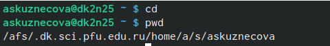

Имя домашнего каталога

# Второй этап

## 2.1

Перейдём в каталог /tmp

## 2.2

Выведем на экран содержимое каталога /tmp с помощью команды ls

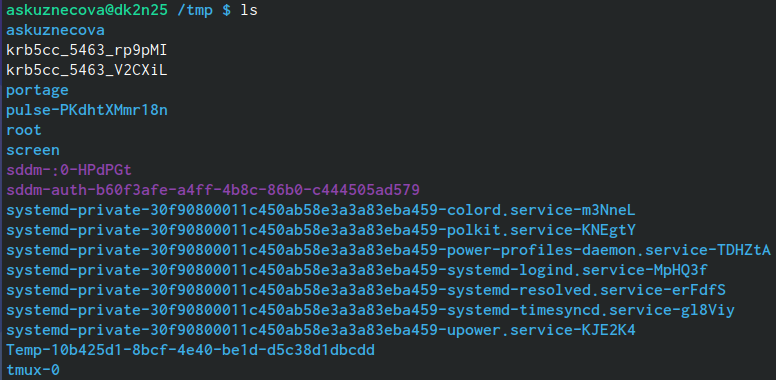

ls

# Сравним команды ls -a и ls -F

## ls -a

Команда ls с опцией -a отображает имена скрытых файлов

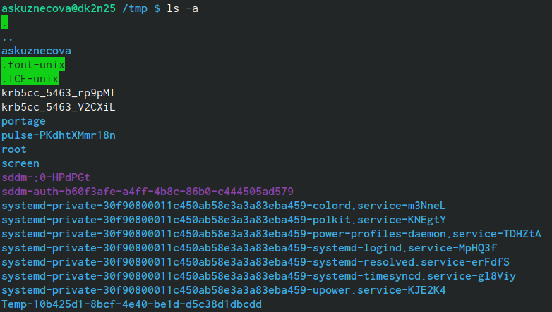

ls -a

## ls -F

Команда ls с опцией -F даёт информацию о типах файлов

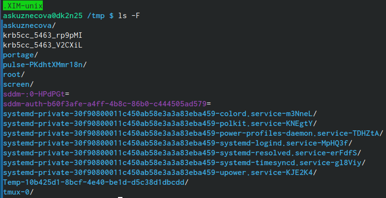

ls -F

## 2.3

Определим, есть ли в каталоге /var/spool подкаталог с именем cron

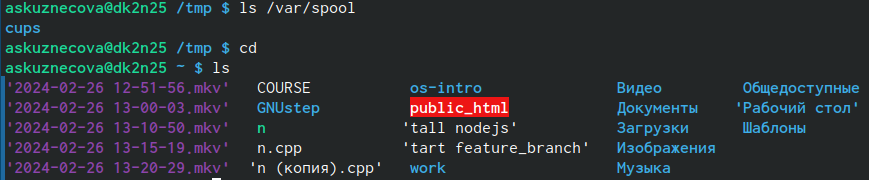

Проверяем содержимое каталога /var/spool

## 2.4

Переходим в домашний каталог и выводим на экран его содержимое.

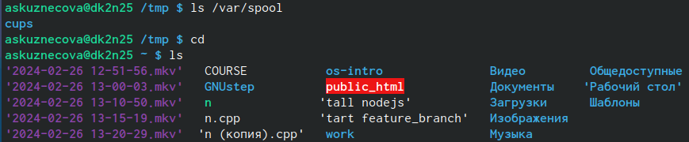

Домашний каталог

Определим, кто является владельцем файлов и подкаталогов с помоью команды ls -l

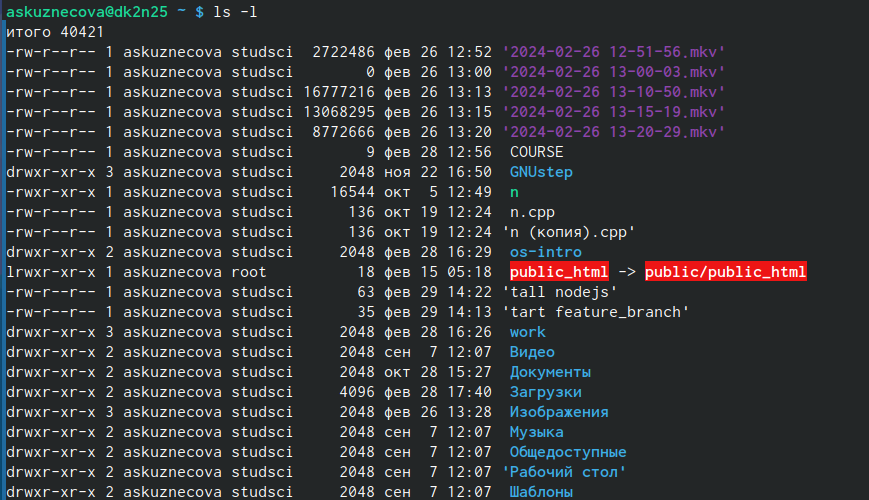

# Третий этап

## 3.1

В домашнем каталоге создаём новый каталог с именем newdir.

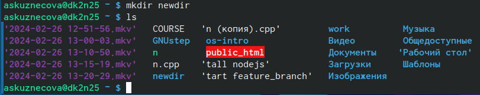

Создание каталога newdir

## 3.2

В каталоге ~/newdir создаём новый каталог с именем morefun.

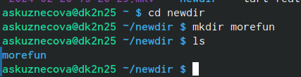

Создание каталога morefun

## 3.3

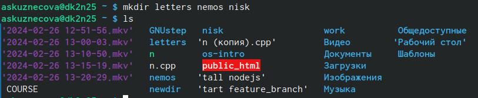

## 3.4

[figure not shown]

# Четвёртый этап

## 4

С помощью команды man определяем, какую опцию команды ls нужно использо- вать для просмотра содержимого не только указанного каталога, но и подкаталогов, входящих в него.

[figure not shown]

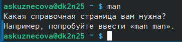

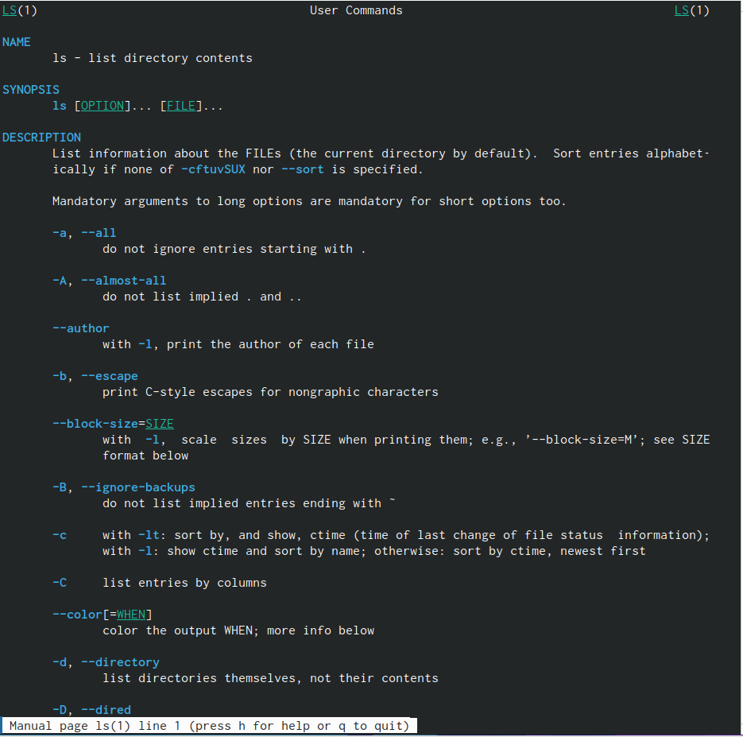

-R, –recursive

Нужно использовать команду ls -R

# Пятый этап

## 5

С помощью команды man определяем набор опций команды ls, позволяющий отсорти- ровать по времени последнего изменения выводимый список содержимого каталога с развёрнутым описанием файлов.

[figure not shown]

# Шестой этап

## 6

Используйте команду man для просмотра описания следующих команд: cd, pwd, mkdir, rmdir, rm. Поясните основные опции этих команд.

[figure not shown]

[figure not shown]

[figure not shown]

[figure not shown]

[figure not shown]

# Седьмой этап

## 7

Получим при помощи команды history

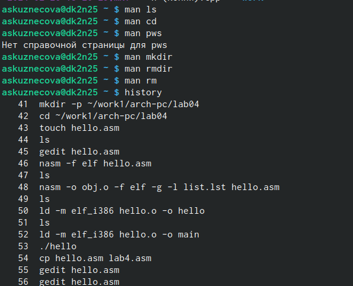

Команда history

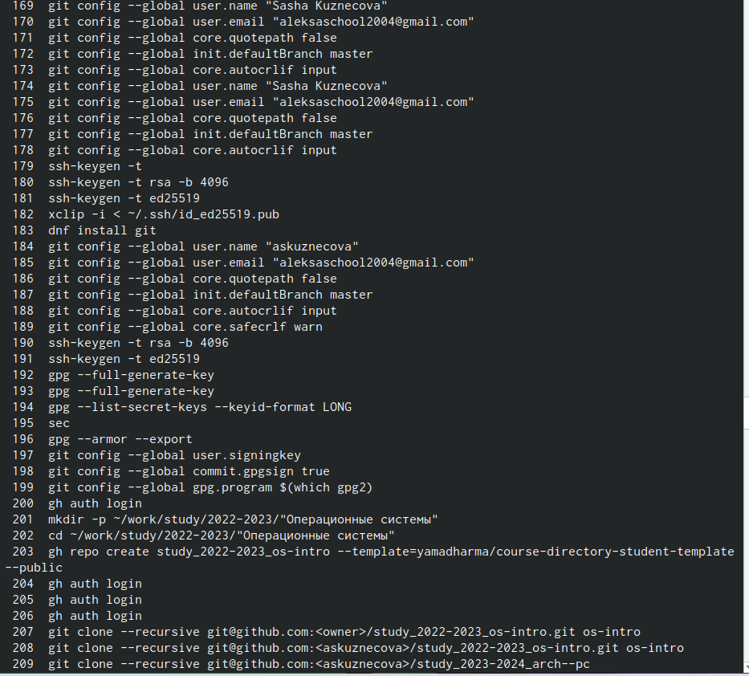

Команда history

Выполним модификацию и исполнение нескольких команд из буфера команд

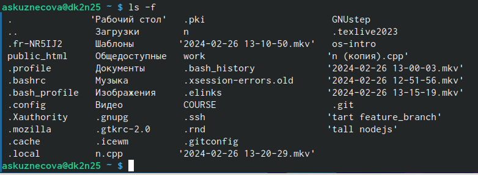

Модификация команды №493

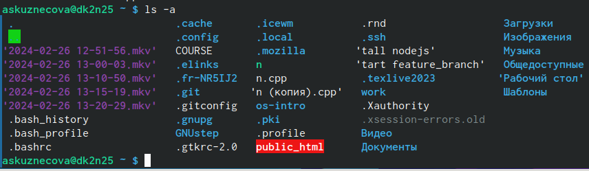

Модификация команды №494

# Вывод

## Выводы

Мы приобрели практические навыки взаимодействия пользователя с системой по- средством командной строки